# SurvivalAnalysisCopenhagenStrokeStudy

Duc-Anh Nguyen

2025-02-02

## EDA

The *cost* dataset from package *pec* collects information from the Copenhagen Stroke Study from 1991 to 1993 (3 years)

```r
#install.packages("pec")
library(pec)
library(tidyverse)
data(cost)
head(cost)
```

```
##    age    sex hypTen ihd prevStroke othDisease alcohol diabetes smoke atrialFib
## 2   80 female     no  no         no        yes      no       no   yes        no
## 3   74   male     no yes        yes         no     yes       no    no        no
## 5   71   male     no  no         no         no     yes       no    no        no
## 6   65 female    yes  no         no         no      no       no    no        no
## 11  69   male    yes  no        yes         no      no       no   yes        no
## 13  72 female    yes yes         no         no     yes       no   yes        no
##    hemor strokeScore cholest time status
## 2     no          55     5.2 1369      1
## 3     no          54     5.6 1657      1
## 5     no          58     6.9 3670      0
## 6     no          44     5.4 4262      0
## 11    no          54     4.7 1157      1
## 13    no          58     5.7 4245      0
```

```r
skimr::skim(cost)
```

Data summary

| Name | cost |
| --- | --- |
| Number of rows | 518 |
| Number of columns | 15 |
| _______________________ |  |
| Column type frequency: |  |
| factor | 10 |
| numeric | 5 |
| ________________________ |  |
| Group variables | None |

**Variable type: factor**

| skim_variable | n_missing | complete_rate | ordered | n_unique | top_counts |
| --- | --- | --- | --- | --- | --- |
| sex | 0 | 1 | FALSE | 2 | fem: 277, mal: 241 |
| hypTen | 0 | 1 | FALSE | 2 | no: 347, yes: 171 |
| ihd | 0 | 1 | FALSE | 2 | no: 416, yes: 102 |
| prevStroke | 0 | 1 | FALSE | 2 | no: 423, yes: 95 |
| othDisease | 0 | 1 | FALSE | 2 | no: 434, yes: 84 |
| alcohol | 0 | 1 | FALSE | 2 | no: 354, yes: 164 |
| diabetes | 0 | 1 | FALSE | 2 | no: 445, yes: 73 |
| smoke | 0 | 1 | FALSE | 2 | no: 282, yes: 236 |
| atrialFib | 0 | 1 | FALSE | 2 | no: 453, yes: 65 |
| hemor | 0 | 1 | FALSE | 2 | no: 492, yes: 26 |

**Variable type: numeric**

| skim_variable | n_missing | complete_rate | mean | sd | p0 | p25 | p50 | p75 | p100 | hist |
| --- | --- | --- | --- | --- | --- | --- | --- | --- | --- | --- |
| age | 0 | 1 | 73.29 | 11.32 | 25.0 | 68.00 | 75.0 | 81.0 | 95.0 | ▁▁▃▇▃ |
| strokeScore | 0 | 1 | 43.53 | 13.01 | 0.0 | 37.00 | 46.0 | 54.0 | 58.0 | ▁▁▂▅▇ |
| cholest | 0 | 1 | 6.00 | 1.39 | 1.5 | 5.10 | 5.9 | 6.8 | 11.6 | ▁▆▇▂▁ |
| time | 0 | 1 | 1920.32 | 1404.46 | 1.0 | 622.25 | 1794.5 | 3286.5 | 4262.0 | ▇▅▅▂▆ |
| status | 0 | 1 | 0.78 | 0.41 | 0.0 | 1.00 | 1.0 | 1.0 | 1.0 | ▂▁▁▁▇ |

*status* is the variable to predict *time* measures the length each patient survived in days, value range from 1 to 4262 (11.5 years)

```r
cost <- cost |> select(time, status, age, sex, alcohol, diabetes, smoke)
dim(cost)
```

```
## [1] 518   7
```

```r
prop.table(table(cost$status))
```

```
##
##         0         1
## 0.2200772 0.7799228
```

```r
colnames(cost)
```

```
## [1] "time"     "status"   "age"      "sex"      "alcohol"  "diabetes" "smoke"
```

```r
skimr::skim(cost)
```

Data summary

| Name | cost |
| --- | --- |
| Number of rows | 518 |
| Number of columns | 7 |
| _______________________ |  |
| Column type frequency: |  |
| factor | 4 |
| numeric | 3 |
| ________________________ |  |
| Group variables | None |

**Variable type: factor**

| skim_variable | n_missing | complete_rate | ordered | n_unique | top_counts |
| --- | --- | --- | --- | --- | --- |
| sex | 0 | 1 | FALSE | 2 | fem: 277, mal: 241 |
| alcohol | 0 | 1 | FALSE | 2 | no: 354, yes: 164 |
| diabetes | 0 | 1 | FALSE | 2 | no: 445, yes: 73 |
| smoke | 0 | 1 | FALSE | 2 | no: 282, yes: 236 |

**Variable type: numeric**

| skim_variable | n_missing | complete_rate | mean | sd | p0 | p25 | p50 | p75 | p100 | hist |
| --- | --- | --- | --- | --- | --- | --- | --- | --- | --- | --- |
| time | 0 | 1 | 1920.32 | 1404.46 | 1 | 622.25 | 1794.5 | 3286.5 | 4262 | ▇▅▅▂▆ |
| status | 0 | 1 | 0.78 | 0.41 | 0 | 1.00 | 1.0 | 1.0 | 1 | ▂▁▁▁▇ |
| age | 0 | 1 | 73.29 | 11.32 | 25 | 68.00 | 75.0 | 81.0 | 95 | ▁▁▃▇▃ |

There are 518 patients in this dataset, 22% from them survived after this study, so their data are right censored. Time and age are the only 2 numerical covariates, the rest are binary

Let us visualise what we have: we try to see what would impact the survival time (in y axis)

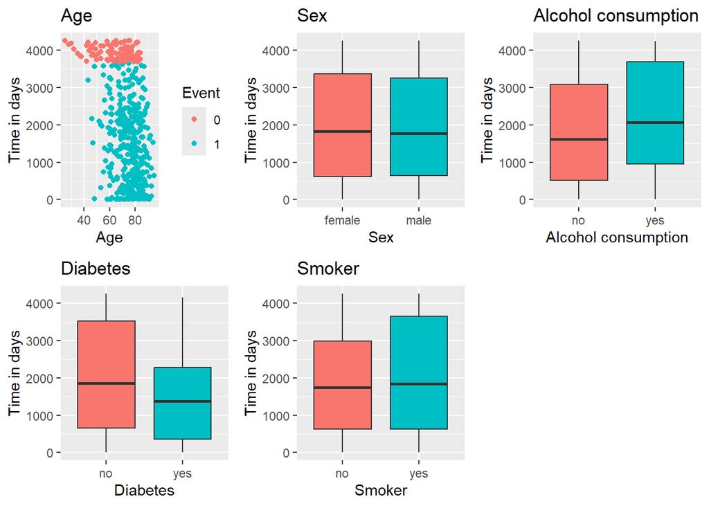

```r
# install.packages("gridExtra")
# age

plot1 <-
  ggplot(mapping = aes(
    x = age,
    y = time,
    color = as.factor(status)
  ),
  data = cost) + geom_point() + theme() + ggtitle("Age") + xlab("Age") + ylab("Time in days") + scale_color_discrete(name = "Event", labels = c("0", "1"))

# sex
plot2 <- ggplot(mapping = aes(x = sex, y = time, fill = sex), data = cost) +
  geom_boxplot() + theme() + ggtitle("Sex") + xlab("Sex") +
  ylab("Time in days") + theme(legend.position = "none")

# alcohol
plot3 <- ggplot(mapping = aes(x = alcohol, y = time, fill = alcohol),
                data = cost) +
  geom_boxplot() + theme() + ggtitle("Alcohol consumption") + xlab("Alcohol consumption") +
  ylab("Time in days") + theme(legend.position = "none")

# diabetes
plot4 <- ggplot(mapping = aes(x = diabetes, y = time, fill = diabetes),
                data = cost) +
  geom_boxplot() + theme() + ggtitle("Diabetes") +
  xlab("Diabetes") + ylab("Time in days") +
  theme(legend.position = "none")

# smoke
plot5 <- ggplot(mapping = aes(x = smoke, y = time, fill = smoke),
                data = cost) +
  geom_boxplot() + theme() + ggtitle("Smoker") + xlab("Smoker") +
  ylab("Time in days") + theme(legend.position = "none")

gridExtra::grid.arrange(plot1, plot2, plot3, plot4, plot5, nrow = 2)
```

+ Age: there is not really much of a pattern here. All the patients younger than 40 yo survived the study + Sex: not much different between the two sexes + With diabetes the survival time is shorter, meanwhile consuming alcohol showing a longer survival time. For smoker the median survival time is no difference from non-smoker.

Now visualising with Kaplan-Meier

```r
library(survival)
library(survminer)
km <- survfit(formula = Surv(time = time, event = status) ~ 1, type = "kaplan-meier", data = cost)
km
```

```
## Call: survfit(formula = Surv(time = time, event = status) ~ 1, data = cost,
##     type = "kaplan-meier")
##
##        n events median 0.95LCL 0.95UCL
## [1,] 518    404   1794    1623    1950
```

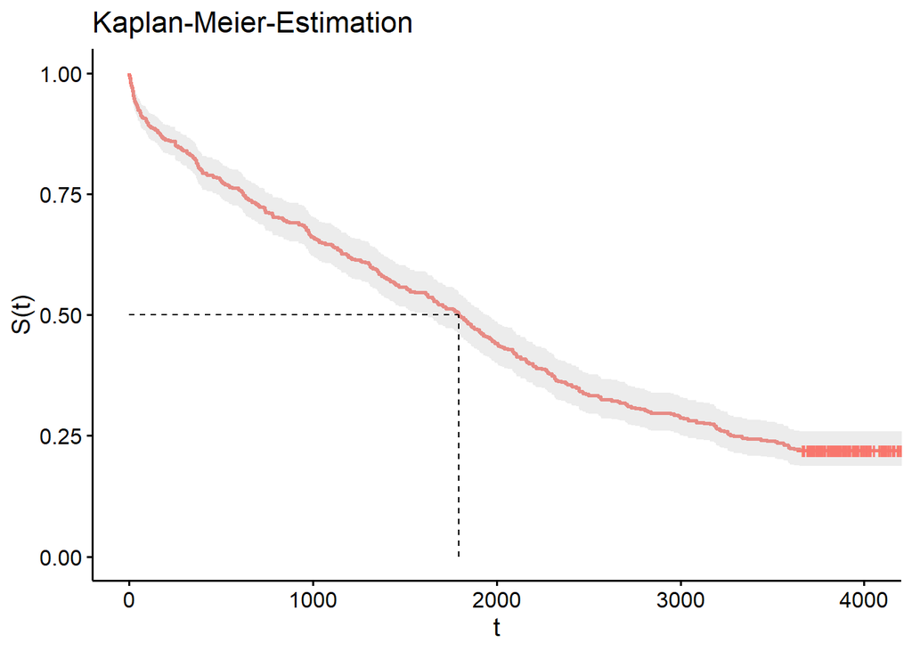

```r
ggsurvplot(fit = km, data = cost, conf.int = TRUE, surv.median.line = "hv", xlab = "t", ylab = "S(t)", legend = "none", title = "Kaplan-Meier-Estimation")
```

50% the patients survived till day 1794 (bit less than 5 years)

Now let us visualise more focusly on each covariates: age, sex, diabtetes, alcohol and smoke. For age we will bin 2 groups: younger than median and older

```r
plots <- list()

# age
cost <-
  cost |> mutate(age_med = ifelse(
    test = age > median(age),
    yes = "yes",
    no = "no"
  ))
km_age_med <-
  survfit(
    formula = Surv(time = time, event = status) ~ age_med,
    type = "kaplan-meier",
    data = cost
  )
km_age_med
```

```
## Call: survfit(formula = Surv(time = time, event = status) ~ age_med,
##     data = cost, type = "kaplan-meier")
##
##               n events median 0.95LCL 0.95UCL
## age_med=no  270    184   2233    2008    2659
## age_med=yes 248    220   1169     978    1452
```

```r
plots[[1]] <-
  ggsurvplot(
    fit = km_age_med,
    data = cost,
    surv.median.line = "hv",
    xlab = "t",
    ylab = "S(t)",
    legend = "bottom",
    legend.title = "",
    title = "Age groups"
  )




# sex:
km_sex <- survfit(
  formula = Surv(time = time, event = status) ~ sex,
  type = "kaplan-meier",
  data = cost
)
km_sex
```

```
## Call: survfit(formula = Surv(time = time, event = status) ~ sex, data = cost,
##     type = "kaplan-meier")
##
##              n events median 0.95LCL 0.95UCL
## sex=female 277    214   1833    1453    2130
## sex=male   241    190   1774    1519    1940
```

```r
plots[[2]] <- ggsurvplot(
  fit = km_sex,
  data = cost,
  surv.median.line = "hv",
  xlab = "t",
  ylab = "S(t)",
  legend = "bottom",
  legend.title = "",
  title = "Geschlecht"
)




# alcohol consumption:
km_alcohol <- survfit(
  formula = Surv(time = time, event = status) ~ alcohol,
  type = "kaplan-meier",
  data = cost
)
km_alcohol
```

```
## Call: survfit(formula = Surv(time = time, event = status) ~ alcohol,
##     data = cost, type = "kaplan-meier")
##
##               n events median 0.95LCL 0.95UCL
## alcohol=no  354    283   1621    1375    1862
## alcohol=yes 164    121   2068    1789    2451
```

```r
plots[[3]] <-
  ggsurvplot(
    fit = km_alcohol,
    data = cost,
    surv.median.line = "hv",
    xlab = "t",
    ylab = "S(t)",
    legend = "bottom",
    legend.title = "",
    title = "Alcohol consumption"
  )


# diabetes:
km_diabetes <- survfit(
  formula = Surv(time = time, event = status) ~ diabetes,
  type = "kaplan-meier",
  data = cost
)
km_diabetes
```

```
## Call: survfit(formula = Surv(time = time, event = status) ~ diabetes,
##     data = cost, type = "kaplan-meier")
##
##                n events median 0.95LCL 0.95UCL
## diabetes=no  445    340   1854    1673    2061
## diabetes=yes  73     64   1375     871    1844
```

```r
plots[[4]] <- ggsurvplot(
  fit = km_diabetes,
  data = cost,
  surv.median.line = "hv",
  xlab = "t",
  ylab = "S(t)",
  legend = "bottom",
  legend.title = "",
  title = "Diabetes"
)


# Smoker:
km_smoke <- survfit(
  formula = Surv(time = time, event = status) ~ smoke,
  type = "kaplan-meier",
  data = cost
)
km_smoke
```

```
## Call: survfit(formula = Surv(time = time, event = status) ~ smoke,
##     data = cost, type = "kaplan-meier")
##
##             n events median 0.95LCL 0.95UCL
## smoke=no  282    227   1748    1453    1918
## smoke=yes 236    177   1838    1507    2314
```

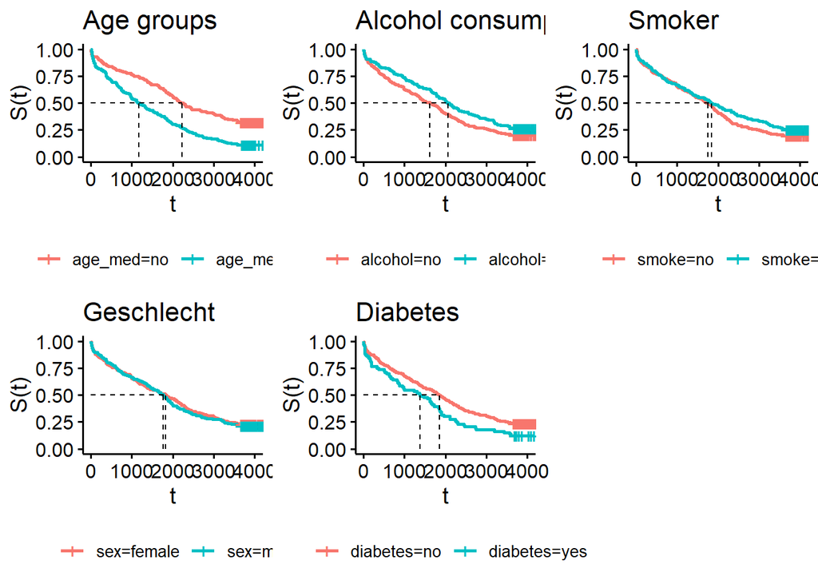

```r
plots[[5]] <-
  ggsurvplot(
    fit = km_smoke,
    data = cost,
    surv.median.line = "hv",
    xlab = "t",
    ylab = "S(t)",
    legend = "bottom",
    legend.title = "",
    title = "Smoker"
  )

arrange_ggsurvplots(plots, nrow = 2, ncol = 3)
```

The Kaplan-Meier Curves allign with our initial visualisations + Age: the younger group has median survival time 2 as long as the older (2233 vs 1169 days) + Just as our first visualisation, the survival chance of people without *diabetes* is higher than people with, and higher for people who drinks alcohol than not drinking + *Smoker*’s chance of survival is not much of a diffence from non-smoker, but only till day 1800, after that smoker has a slightly higher chance of suvive

With Kaplan-Meier curve we can only see effect of each covariate. Now we want to fit a regression model for multivariate analysis!

## Analysis of suvival time of stroke patient with *Cox model*

```r
model <- survival::coxph(formula = Surv(time, status)~age + sex + alcohol + diabetes + smoke, data = cost)
summary(model)
```

```
## Call:
## survival::coxph(formula = Surv(time, status) ~ age + sex + alcohol +
##     diabetes + smoke, data = cost)
##
##   n= 518, number of events= 404
##
##                 coef exp(coef) se(coef)      z Pr(>|z|)
## age          0.05494   1.05648  0.00608  9.036  < 2e-16 ***
## sexmale      0.33749   1.40143  0.10861  3.107  0.00189 **
## alcoholyes  -0.08619   0.91742  0.11885 -0.725  0.46834
## diabetesyes  0.44093   1.55416  0.13850  3.184  0.00145 **
## smokeyes     0.25704   1.29310  0.10971  2.343  0.01914 *
## ---
## Signif. codes:  0 '***' 0.001 '**' 0.01 '*' 0.05 '.' 0.1 ' ' 1
##
##             exp(coef) exp(-coef) lower .95 upper .95
## age            1.0565     0.9465    1.0440     1.069
## sexmale        1.4014     0.7136    1.1327     1.734
## alcoholyes     0.9174     1.0900    0.7268     1.158
## diabetesyes    1.5542     0.6434    1.1847     2.039
## smokeyes       1.2931     0.7733    1.0429     1.603
##
## Concordance= 0.647  (se = 0.014 )
## Likelihood ratio test= 110.9  on 5 df,   p=<2e-16
## Wald test            = 93.77  on 5 df,   p=<2e-16
## Score (logrank) test = 92.77  on 5 df,   p=<2e-16
```